# Risk Factor Analysis

## Outcome Variable

**Outcome Variable:** stunted

## Predictor Variables

**Intervention Variable:** feducyrs

**Adjustment Set:**

- arm
- W_mage
- meducyrs
- hhwealth_quart
- W_mhtcm
- W_gagebrth
- W_birthwt
- W_birthlen
- W_nrooms
- W_nchldlt5
- impfloor
- impsan
- safeh20
- delta_W_mage
- delta_meducyrs
- delta_hhwealth_quart
- delta_W_mhtcm
- delta_W_gagebrth
- delta_W_birthwt
- delta_W_birthlen
- delta_W_nrooms
- delta_W_nchldlt5
- delta_impfloor
- delta_impsan
- delta_safeh20

## Stratifying Variables

The analysis was stratified on these variable(s):

- agecat
- studyid
- country

## Data Summary

| agecat | studyid | country | feducyrs | stunted | n_cell | n |
| --- | --- | --- | --- | --- | --- | --- |
| Birth | ki0047075b-MAL-ED | BANGLADESH | Low | 0 | 30 | 144 |
| Birth | ki0047075b-MAL-ED | BANGLADESH | Low | 1 | 8 | 144 |
| Birth | ki0047075b-MAL-ED | BANGLADESH | Medium | 0 | 44 | 144 |
| Birth | ki0047075b-MAL-ED | BANGLADESH | Medium | 1 | 10 | 144 |
| Birth | ki0047075b-MAL-ED | BANGLADESH | High | 0 | 44 | 144 |
| Birth | ki0047075b-MAL-ED | BANGLADESH | High | 1 | 8 | 144 |
| Birth | ki0047075b-MAL-ED | INDIA | Low | 0 | 46 | 123 |
| Birth | ki0047075b-MAL-ED | INDIA | Low | 1 | 4 | 123 |
| Birth | ki0047075b-MAL-ED | INDIA | Medium | 0 | 30 | 123 |
| Birth | ki0047075b-MAL-ED | INDIA | Medium | 1 | 5 | 123 |
| Birth | ki0047075b-MAL-ED | INDIA | High | 0 | 32 | 123 |
| Birth | ki0047075b-MAL-ED | INDIA | High | 1 | 6 | 123 |
| Birth | ki0047075b-MAL-ED | NEPAL | Low | 0 | 17 | 67 |
| Birth | ki0047075b-MAL-ED | NEPAL | Low | 1 | 2 | 67 |
| Birth | ki0047075b-MAL-ED | NEPAL | Medium | 0 | 16 | 67 |
| Birth | ki0047075b-MAL-ED | NEPAL | Medium | 1 | 5 | 67 |
| Birth | ki0047075b-MAL-ED | NEPAL | High | 0 | 26 | 67 |
| Birth | ki0047075b-MAL-ED | NEPAL | High | 1 | 1 | 67 |
| Birth | ki0047075b-MAL-ED | PERU | Low | 0 | 52 | 236 |
| Birth | ki0047075b-MAL-ED | PERU | Low | 1 | 13 | 236 |
| Birth | ki0047075b-MAL-ED | PERU | Medium | 0 | 52 | 236 |
| Birth | ki0047075b-MAL-ED | PERU | Medium | 1 | 3 | 236 |
| Birth | ki0047075b-MAL-ED | PERU | High | 0 | 106 | 236 |
| Birth | ki0047075b-MAL-ED | PERU | High | 1 | 10 | 236 |
| Birth | ki0047075b-MAL-ED | SOUTH AFRICA | Low | 0 | 30 | 91 |
| Birth | ki0047075b-MAL-ED | SOUTH AFRICA | Low | 1 | 0 | 91 |
| Birth | ki0047075b-MAL-ED | SOUTH AFRICA | Medium | 0 | 23 | 91 |
| Birth | ki0047075b-MAL-ED | SOUTH AFRICA | Medium | 1 | 3 | 91 |
| Birth | ki0047075b-MAL-ED | SOUTH AFRICA | High | 0 | 30 | 91 |
| Birth | ki0047075b-MAL-ED | SOUTH AFRICA | High | 1 | 5 | 91 |

[output cut: 288 more lines]

The following strata were considered:

- agecat: 24 months, studyid: ki0047075b-MAL-ED, country: BANGLADESH
- agecat: 24 months, studyid: ki0047075b-MAL-ED, country: INDIA
- agecat: 24 months, studyid: ki0047075b-MAL-ED, country: NEPAL
- agecat: 24 months, studyid: ki0047075b-MAL-ED, country: PERU
- agecat: 24 months, studyid: ki0047075b-MAL-ED, country: SOUTH AFRICA
- agecat: 24 months, studyid: ki0047075b-MAL-ED, country: TANZANIA, UNITED REPUBLIC OF
- agecat: 24 months, studyid: ki1017093b-PROVIDE, country: BANGLADESH
- agecat: 24 months, studyid: ki1017093c-NIH-Crypto, country: BANGLADESH
- agecat: 24 months, studyid: ki1066203-TanzaniaChild2, country: TANZANIA, UNITED REPUBLIC OF
- agecat: 24 months, studyid: ki1113344-GMS-Nepal, country: NEPAL
- agecat: 24 months, studyid: ki1119695-PROBIT, country: BELARUS
- agecat: 24 months, studyid: ki1126311-ZVITAMBO, country: ZIMBABWE
- agecat: 24 months, studyid: ki1135781-COHORTS, country: GUATEMALA
- agecat: 24 months, studyid: ki1135781-COHORTS, country: INDIA
- agecat: 24 months, studyid: ki1135781-COHORTS, country: PHILIPPINES
- agecat: 24 months, studyid: ki1148112-LCNI-5, country: MALAWI
- agecat: 24 months, studyid: kiGH5241-JiVitA-3, country: BANGLADESH
- agecat: 24 months, studyid: kiGH5241-JiVitA-4, country: BANGLADESH
- agecat: 6 months, studyid: ki0047075b-MAL-ED, country: BANGLADESH
- agecat: 6 months, studyid: ki0047075b-MAL-ED, country: INDIA
- agecat: 6 months, studyid: ki0047075b-MAL-ED, country: NEPAL
- agecat: 6 months, studyid: ki0047075b-MAL-ED, country: PERU
- agecat: 6 months, studyid: ki0047075b-MAL-ED, country: SOUTH AFRICA
- agecat: 6 months, studyid: ki0047075b-MAL-ED, country: TANZANIA, UNITED REPUBLIC OF
- agecat: 6 months, studyid: ki1000304b-SAS-CompFeed, country: INDIA
- agecat: 6 months, studyid: ki1000304b-SAS-FoodSuppl, country: INDIA
- agecat: 6 months, studyid: ki1017093b-PROVIDE, country: BANGLADESH
- agecat: 6 months, studyid: ki1017093c-NIH-Crypto, country: BANGLADESH
- agecat: 6 months, studyid: ki1066203-TanzaniaChild2, country: TANZANIA, UNITED REPUBLIC OF
- agecat: 6 months, studyid: ki1113344-GMS-Nepal, country: NEPAL
- agecat: 6 months, studyid: ki1119695-PROBIT, country: BELARUS
- agecat: 6 months, studyid: ki1126311-ZVITAMBO, country: ZIMBABWE
- agecat: 6 months, studyid: ki1135781-COHORTS, country: GUATEMALA
- agecat: 6 months, studyid: ki1135781-COHORTS, country: INDIA
- agecat: 6 months, studyid: ki1135781-COHORTS, country: PHILIPPINES
- agecat: 6 months, studyid: ki1148112-LCNI-5, country: MALAWI
- agecat: 6 months, studyid: kiGH5241-JiVitA-3, country: BANGLADESH
- agecat: 6 months, studyid: kiGH5241-JiVitA-4, country: BANGLADESH
- agecat: Birth, studyid: ki0047075b-MAL-ED, country: BANGLADESH
- agecat: Birth, studyid: ki0047075b-MAL-ED, country: INDIA
- agecat: Birth, studyid: ki0047075b-MAL-ED, country: NEPAL
- agecat: Birth, studyid: ki0047075b-MAL-ED, country: PERU
- agecat: Birth, studyid: ki0047075b-MAL-ED, country: SOUTH AFRICA
- agecat: Birth, studyid: ki0047075b-MAL-ED, country: TANZANIA, UNITED REPUBLIC OF
- agecat: Birth, studyid: ki1000304b-SAS-CompFeed, country: INDIA
- agecat: Birth, studyid: ki1017093c-NIH-Crypto, country: BANGLADESH
- agecat: Birth, studyid: ki1119695-PROBIT, country: BELARUS
- agecat: Birth, studyid: ki1126311-ZVITAMBO, country: ZIMBABWE
- agecat: Birth, studyid: ki1135781-COHORTS, country: GUATEMALA
- agecat: Birth, studyid: ki1135781-COHORTS, country: INDIA
- agecat: Birth, studyid: ki1135781-COHORTS, country: PHILIPPINES
- agecat: Birth, studyid: kiGH5241-JiVitA-3, country: BANGLADESH
- agecat: Birth, studyid: kiGH5241-JiVitA-4, country: BANGLADESH

### Dropped Strata

Some strata were dropped due to rare outcomes:

- agecat: Birth, studyid: ki0047075b-MAL-ED, country: INDIA
- agecat: Birth, studyid: ki0047075b-MAL-ED, country: NEPAL
- agecat: Birth, studyid: ki0047075b-MAL-ED, country: PERU
- agecat: Birth, studyid: ki0047075b-MAL-ED, country: SOUTH AFRICA
- agecat: Birth, studyid: ki0047075b-MAL-ED, country: TANZANIA, UNITED REPUBLIC OF
- agecat: Birth, studyid: ki1000304b-SAS-CompFeed, country: INDIA
- agecat: Birth, studyid: ki1017093c-NIH-Crypto, country: BANGLADESH
- agecat: Birth, studyid: ki1119695-PROBIT, country: BELARUS
- agecat: 6 months, studyid: ki0047075b-MAL-ED, country: NEPAL
- agecat: 6 months, studyid: ki0047075b-MAL-ED, country: SOUTH AFRICA
- agecat: 24 months, studyid: ki0047075b-MAL-ED, country: TANZANIA, UNITED REPUBLIC OF
- agecat: 24 months, studyid: ki1066203-TanzaniaChild2, country: TANZANIA, UNITED REPUBLIC OF

## Methods Detail

We’re interested in the causal parameters $E[Y_a]$ for all values of $a \in \mathcal{A}$. These parameters represent the mean outcome if, possibly contrary to fact, we intervened to set all units to have $A=a$. Under the randomization and positivity assumptions, these are identified by the statistical parameters $\psi_a=E_W[E_{Y|A,W}(Y|A=a,W)]$. In addition, we’re interested in the mean of $Y$, $E[Y]$ under no intervention (the observed mean). We will estimate these parameters by using SuperLearner to fit the relevant likelihood factors – $E_{Y|A,W}(Y|A=a,W)$ and $p(A=a|W)$, and then updating our likelihood fit using a joint TMLE.

For unadjusted analyses ($W=\{\}$), initial likelihoods were estimated using Lrnr_glm to estimate the simple $E(Y|A)$ and Lrnr_mean to estimate $p(A)$. For adjusted analyses, a small library containing Lrnr_glmnet, Lrnr_xgboost, and Lrnr_mean was used.

Having estimated these parameters, we will then use the delta method to estimate relative risks and attributable risks relative to a prespecified baseline level of $A$.

# Results Detail

## Results Plots

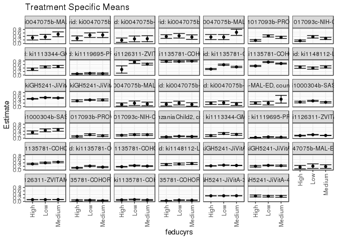

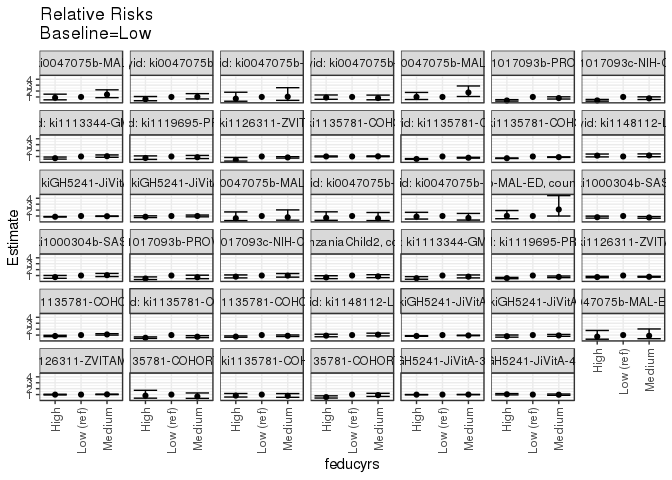

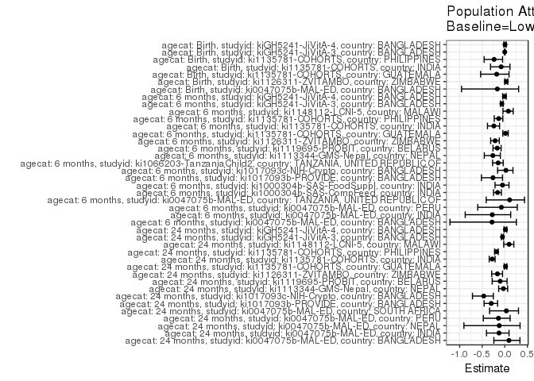

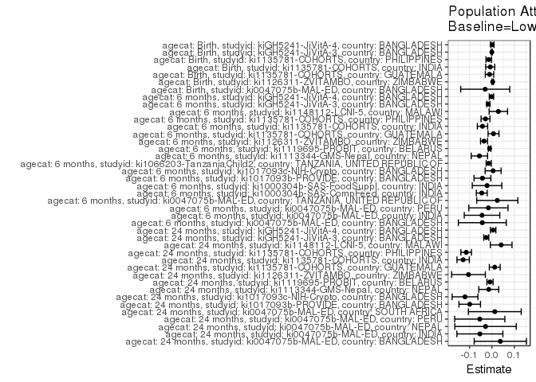

## Results Table

### Parameter: TSM

| agecat | studyid | country | intervention_level | baseline_level | estimate | ci_lower | ci_upper |
| --- | --- | --- | --- | --- | --- | --- | --- |
| Birth | ki0047075b-MAL-ED | BANGLADESH | Low | NA | 0.2105263 | 0.0804520 | 0.3406006 |
| Birth | ki0047075b-MAL-ED | BANGLADESH | Medium | NA | 0.1851852 | 0.0812178 | 0.2891525 |
| Birth | ki0047075b-MAL-ED | BANGLADESH | High | NA | 0.1538462 | 0.0554388 | 0.2522535 |
| Birth | ki1126311-ZVITAMBO | ZIMBABWE | Low | NA | 0.0996349 | 0.0935737 | 0.1056962 |
| Birth | ki1126311-ZVITAMBO | ZIMBABWE | Medium | NA | 0.1032356 | 0.0980245 | 0.1084468 |
| Birth | ki1126311-ZVITAMBO | ZIMBABWE | High | NA | 0.0992058 | 0.0924215 | 0.1059900 |
| Birth | ki1135781-COHORTS | GUATEMALA | Low | NA | 0.0704225 | 0.0437906 | 0.0970545 |
| Birth | ki1135781-COHORTS | GUATEMALA | Medium | NA | 0.0476190 | 0.0232611 | 0.0719770 |
| Birth | ki1135781-COHORTS | GUATEMALA | High | NA | 0.0580645 | 0.0212246 | 0.0949044 |
| Birth | ki1135781-COHORTS | INDIA | Low | NA | 0.1028919 | 0.0770805 | 0.1287034 |
| Birth | ki1135781-COHORTS | INDIA | Medium | NA | 0.0815864 | 0.0570025 | 0.1061703 |
| Birth | ki1135781-COHORTS | INDIA | High | NA | 0.0855333 | 0.0635266 | 0.1075400 |
| Birth | ki1135781-COHORTS | PHILIPPINES | Low | NA | 0.0744955 | 0.0587374 | 0.0902536 |
| Birth | ki1135781-COHORTS | PHILIPPINES | Medium | NA | 0.0680638 | 0.0539563 | 0.0821713 |
| Birth | ki1135781-COHORTS | PHILIPPINES | High | NA | 0.0427056 | 0.0320297 | 0.0533815 |
| Birth | kiGH5241-JiVitA-3 | BANGLADESH | Low | NA | 0.3222195 | 0.3141595 | 0.3302795 |
| Birth | kiGH5241-JiVitA-3 | BANGLADESH | Medium | NA | 0.3237088 | 0.3153019 | 0.3321157 |
| Birth | kiGH5241-JiVitA-3 | BANGLADESH | High | NA | 0.3196284 | 0.3110046 | 0.3282523 |
| Birth | kiGH5241-JiVitA-4 | BANGLADESH | Low | NA | 0.2956521 | 0.2487026 | 0.3426016 |
| Birth | kiGH5241-JiVitA-4 | BANGLADESH | Medium | NA | 0.2895151 | 0.2369052 | 0.3421250 |
| Birth | kiGH5241-JiVitA-4 | BANGLADESH | High | NA | 0.3108330 | 0.2574755 | 0.3641906 |
| 6 months | ki0047075b-MAL-ED | BANGLADESH | Low | NA | 0.1944444 | 0.0646687 | 0.3242202 |
| 6 months | ki0047075b-MAL-ED | BANGLADESH | Medium | NA | 0.1521739 | 0.0479796 | 0.2563682 |
| 6 months | ki0047075b-MAL-ED | BANGLADESH | High | NA | 0.1200000 | 0.0295838 | 0.2104162 |
| 6 months | ki0047075b-MAL-ED | INDIA | Low | NA | 0.2037037 | 0.0958917 | 0.3115157 |
| 6 months | ki0047075b-MAL-ED | INDIA | Medium | NA | 0.1219512 | 0.0214230 | 0.2224794 |
| 6 months | ki0047075b-MAL-ED | INDIA | High | NA | 0.1395349 | 0.0355905 | 0.2434793 |
| 6 months | ki0047075b-MAL-ED | PERU | Low | NA | 0.2210544 | 0.1172268 | 0.3248820 |
| 6 months | ki0047075b-MAL-ED | PERU | Medium | NA | 0.1482170 | 0.0595848 | 0.2368492 |
| 6 months | ki0047075b-MAL-ED | PERU | High | NA | 0.1957977 | 0.1214798 | 0.2701156 |

[output cut: 93 more lines]

### Parameter: E(Y)

| agecat | studyid | country | intervention_level | baseline_level | estimate | ci_lower | ci_upper |
| --- | --- | --- | --- | --- | --- | --- | --- |
| Birth | ki0047075b-MAL-ED | BANGLADESH | NA | NA | 0.1805556 | 0.1175113 | 0.2435998 |
| Birth | ki1126311-ZVITAMBO | ZIMBABWE | NA | NA | 0.1029718 | 0.0978372 | 0.1081063 |
| Birth | ki1135781-COHORTS | GUATEMALA | NA | NA | 0.0597015 | 0.0433139 | 0.0760891 |
| Birth | ki1135781-COHORTS | INDIA | NA | NA | 0.0952733 | 0.0796294 | 0.1109171 |
| Birth | ki1135781-COHORTS | PHILIPPINES | NA | NA | 0.0602158 | 0.0515157 | 0.0689159 |
| Birth | kiGH5241-JiVitA-3 | BANGLADESH | NA | NA | 0.3218470 | 0.3140700 | 0.3296240 |
| Birth | kiGH5241-JiVitA-4 | BANGLADESH | NA | NA | 0.2971175 | 0.2506806 | 0.3435544 |
| 6 months | ki0047075b-MAL-ED | BANGLADESH | NA | NA | 0.1515152 | 0.0901160 | 0.2129143 |
| 6 months | ki0047075b-MAL-ED | INDIA | NA | NA | 0.1594203 | 0.0981219 | 0.2207187 |
| 6 months | ki0047075b-MAL-ED | PERU | NA | NA | 0.2053571 | 0.1523375 | 0.2583768 |
| 6 months | ki0047075b-MAL-ED | TANZANIA, UNITED REPUBLIC OF | NA | NA | 0.2238806 | 0.1661102 | 0.2816510 |
| 6 months | ki1000304b-SAS-CompFeed | INDIA | NA | NA | 0.2835709 | 0.2656121 | 0.3015297 |
| 6 months | ki1000304b-SAS-FoodSuppl | INDIA | NA | NA | 0.4289474 | 0.3791199 | 0.4787748 |
| 6 months | ki1017093b-PROVIDE | BANGLADESH | NA | NA | 0.1612350 | 0.1313580 | 0.1911120 |
| 6 months | ki1017093c-NIH-Crypto | BANGLADESH | NA | NA | 0.2097902 | 0.1799252 | 0.2396552 |
| 6 months | ki1066203-TanzaniaChild2 | TANZANIA, UNITED REPUBLIC OF | NA | NA | 0.0966303 | 0.0837364 | 0.1095242 |
| 6 months | ki1113344-GMS-Nepal | NEPAL | NA | NA | 0.2117438 | 0.1779368 | 0.2455507 |
| 6 months | ki1119695-PROBIT | BELARUS | NA | NA | 0.0613372 | 0.0479409 | 0.0747335 |
| 6 months | ki1126311-ZVITAMBO | ZIMBABWE | NA | NA | 0.1645789 | 0.1564849 | 0.1726730 |
| 6 months | ki1135781-COHORTS | GUATEMALA | NA | NA | 0.4059735 | 0.3739435 | 0.4380034 |
| 6 months | ki1135781-COHORTS | INDIA | NA | NA | 0.1732852 | 0.1533446 | 0.1932258 |
| 6 months | ki1135781-COHORTS | PHILIPPINES | NA | NA | 0.2113885 | 0.1955816 | 0.2271953 |
| 6 months | ki1148112-LCNI-5 | MALAWI | NA | NA | 0.3633005 | 0.3301997 | 0.3964012 |
| 6 months | kiGH5241-JiVitA-3 | BANGLADESH | NA | NA | 0.2492707 | 0.2410138 | 0.2575276 |
| 6 months | kiGH5241-JiVitA-4 | BANGLADESH | NA | NA | 0.2491156 | 0.2297596 | 0.2684716 |
| 24 months | ki0047075b-MAL-ED | BANGLADESH | NA | NA | 0.4102564 | 0.3207450 | 0.4997678 |
| 24 months | ki0047075b-MAL-ED | INDIA | NA | NA | 0.4166667 | 0.3322428 | 0.5010905 |
| 24 months | ki0047075b-MAL-ED | NEPAL | NA | NA | 0.2307692 | 0.1437242 | 0.3178143 |
| 24 months | ki0047075b-MAL-ED | PERU | NA | NA | 0.3841463 | 0.3094772 | 0.4588155 |
| 24 months | ki0047075b-MAL-ED | SOUTH AFRICA | NA | NA | 0.3736264 | 0.2736811 | 0.4735717 |
| 24 months | ki1017093b-PROVIDE | BANGLADESH | NA | NA | 0.3292894 | 0.2909105 | 0.3676684 |
| 24 months | ki1017093c-NIH-Crypto | BANGLADESH | NA | NA | 0.2568093 | 0.2190047 | 0.2946140 |
| 24 months | ki1113344-GMS-Nepal | NEPAL | NA | NA | 0.4477912 | 0.4040733 | 0.4915091 |
| 24 months | ki1119695-PROBIT | BELARUS | NA | NA | 0.0845898 | 0.0544909 | 0.1146887 |
| 24 months | ki1126311-ZVITAMBO | ZIMBABWE | NA | NA | 0.6382488 | 0.5929899 | 0.6835078 |
| 24 months | ki1135781-COHORTS | GUATEMALA | NA | NA | 0.7879397 | 0.7625282 | 0.8133512 |
| 24 months | ki1135781-COHORTS | INDIA | NA | NA | 0.4608696 | 0.4345607 | 0.4871784 |
| 24 months | ki1135781-COHORTS | PHILIPPINES | NA | NA | 0.6214347 | 0.6016683 | 0.6412012 |
| 24 months | ki1148112-LCNI-5 | MALAWI | NA | NA | 0.4360771 | 0.3953670 | 0.4767872 |
| 24 months | kiGH5241-JiVitA-3 | BANGLADESH | NA | NA | 0.4886096 | 0.4753690 | 0.5018502 |
| 24 months | kiGH5241-JiVitA-4 | BANGLADESH | NA | NA | 0.3880966 | 0.3646676 | 0.4115256 |

### Parameter: RR

| agecat | studyid | country | intervention_level | baseline_level | estimate | ci_lower | ci_upper |
| --- | --- | --- | --- | --- | --- | --- | --- |
| Birth | ki0047075b-MAL-ED | BANGLADESH | Low | Low | 1.0000000 | 1.0000000 | 1.0000000 |
| Birth | ki0047075b-MAL-ED | BANGLADESH | Medium | Low | 0.8796296 | 0.3817142 | 2.0270354 |
| Birth | ki0047075b-MAL-ED | BANGLADESH | High | Low | 0.7307692 | 0.3002984 | 1.7783099 |
| Birth | ki1126311-ZVITAMBO | ZIMBABWE | Low | Low | 1.0000000 | 1.0000000 | 1.0000000 |
| Birth | ki1126311-ZVITAMBO | ZIMBABWE | Medium | Low | 1.0361391 | 0.9940896 | 1.0799672 |
| Birth | ki1126311-ZVITAMBO | ZIMBABWE | High | Low | 0.9956928 | 0.9365622 | 1.0585567 |
| Birth | ki1135781-COHORTS | GUATEMALA | Low | Low | 1.0000000 | 1.0000000 | 1.0000000 |
| Birth | ki1135781-COHORTS | GUATEMALA | Medium | Low | 0.6761905 | 0.3579318 | 1.2774321 |
| Birth | ki1135781-COHORTS | GUATEMALA | High | Low | 0.8245161 | 0.3939310 | 1.7257513 |
| Birth | ki1135781-COHORTS | INDIA | Low | Low | 1.0000000 | 1.0000000 | 1.0000000 |
| Birth | ki1135781-COHORTS | INDIA | Medium | Low | 0.7929332 | 0.5389942 | 1.1665118 |
| Birth | ki1135781-COHORTS | INDIA | High | Low | 0.8312924 | 0.5836498 | 1.1840096 |
| Birth | ki1135781-COHORTS | PHILIPPINES | Low | Low | 1.0000000 | 1.0000000 | 1.0000000 |
| Birth | ki1135781-COHORTS | PHILIPPINES | Medium | Low | 0.9136639 | 0.6849898 | 1.2186776 |
| Birth | ki1135781-COHORTS | PHILIPPINES | High | Low | 0.5732641 | 0.4159383 | 0.7900975 |
| Birth | kiGH5241-JiVitA-3 | BANGLADESH | Low | Low | 1.0000000 | 1.0000000 | 1.0000000 |
| Birth | kiGH5241-JiVitA-3 | BANGLADESH | Medium | Low | 1.0046219 | 0.9908005 | 1.0186361 |
| Birth | kiGH5241-JiVitA-3 | BANGLADESH | High | Low | 0.9919586 | 0.9752700 | 1.0089328 |
| Birth | kiGH5241-JiVitA-4 | BANGLADESH | Low | Low | 1.0000000 | 1.0000000 | 1.0000000 |
| Birth | kiGH5241-JiVitA-4 | BANGLADESH | Medium | Low | 0.9792426 | 0.8760757 | 1.0945583 |
| Birth | kiGH5241-JiVitA-4 | BANGLADESH | High | Low | 1.0513473 | 0.9455022 | 1.1690413 |
| 6 months | ki0047075b-MAL-ED | BANGLADESH | Low | Low | 1.0000000 | 1.0000000 | 1.0000000 |
| 6 months | ki0047075b-MAL-ED | BANGLADESH | Medium | Low | 0.7826087 | 0.3008040 | 2.0361313 |
| 6 months | ki0047075b-MAL-ED | BANGLADESH | High | Low | 0.6171429 | 0.2255498 | 1.6886084 |
| 6 months | ki0047075b-MAL-ED | INDIA | Low | Low | 1.0000000 | 1.0000000 | 1.0000000 |
| 6 months | ki0047075b-MAL-ED | INDIA | Medium | Low | 0.5986696 | 0.2247749 | 1.5945080 |
| 6 months | ki0047075b-MAL-ED | INDIA | High | Low | 0.6849894 | 0.2746771 | 1.7082256 |
| 6 months | ki0047075b-MAL-ED | PERU | Low | Low | 1.0000000 | 1.0000000 | 1.0000000 |
| 6 months | ki0047075b-MAL-ED | PERU | Medium | Low | 0.6705001 | 0.3134241 | 1.4343838 |
| 6 months | ki0047075b-MAL-ED | PERU | High | Low | 0.8857443 | 0.4839700 | 1.6210573 |

[output cut: 93 more lines]

### Parameter: PAR

| agecat | studyid | country | intervention_level | baseline_level | estimate | ci_lower | ci_upper |
| --- | --- | --- | --- | --- | --- | --- | --- |
| Birth | ki0047075b-MAL-ED | BANGLADESH | Low | NA | -0.0299708 | -0.1393520 | 0.0794105 |
| Birth | ki1126311-ZVITAMBO | ZIMBABWE | Low | NA | 0.0033368 | -0.0001599 | 0.0068336 |
| Birth | ki1135781-COHORTS | GUATEMALA | Low | NA | -0.0107210 | -0.0294688 | 0.0080267 |
| Birth | ki1135781-COHORTS | INDIA | Low | NA | -0.0076187 | -0.0279951 | 0.0127577 |
| Birth | ki1135781-COHORTS | PHILIPPINES | Low | NA | -0.0142797 | -0.0265606 | -0.0019988 |
| Birth | kiGH5241-JiVitA-3 | BANGLADESH | Low | NA | -0.0003725 | -0.0027128 | 0.0019677 |
| Birth | kiGH5241-JiVitA-4 | BANGLADESH | Low | NA | 0.0014654 | -0.0061808 | 0.0091117 |
| 6 months | ki0047075b-MAL-ED | BANGLADESH | Low | NA | -0.0429293 | -0.1498180 | 0.0639594 |
| 6 months | ki0047075b-MAL-ED | INDIA | Low | NA | -0.0442834 | -0.1235572 | 0.0349903 |
| 6 months | ki0047075b-MAL-ED | PERU | Low | NA | -0.0156973 | -0.1033223 | 0.0719277 |
| 6 months | ki0047075b-MAL-ED | TANZANIA, UNITED REPUBLIC OF | Low | NA | 0.0238806 | -0.0678915 | 0.1156527 |
| 6 months | ki1000304b-SAS-CompFeed | INDIA | Low | NA | -0.0453183 | -0.0696525 | -0.0209841 |
| 6 months | ki1000304b-SAS-FoodSuppl | INDIA | Low | NA | -0.0218032 | -0.0878393 | 0.0442329 |
| 6 months | ki1017093b-PROVIDE | BANGLADESH | Low | NA | -0.0422780 | -0.0797359 | -0.0048202 |
| 6 months | ki1017093c-NIH-Crypto | BANGLADESH | Low | NA | 0.0053244 | -0.0301754 | 0.0408242 |
| 6 months | ki1066203-TanzaniaChild2 | TANZANIA, UNITED REPUBLIC OF | Low | NA | -0.0142562 | -0.0256700 | -0.0028423 |
| 6 months | ki1113344-GMS-Nepal | NEPAL | Low | NA | -0.0559905 | -0.0923985 | -0.0195826 |
| 6 months | ki1119695-PROBIT | BELARUS | Low | NA | -0.0103371 | -0.0159626 | -0.0047116 |
| 6 months | ki1126311-ZVITAMBO | ZIMBABWE | Low | NA | -0.0352966 | -0.0508661 | -0.0197270 |
| 6 months | ki1135781-COHORTS | GUATEMALA | Low | NA | 0.0070063 | -0.0172964 | 0.0313090 |
| 6 months | ki1135781-COHORTS | INDIA | Low | NA | -0.0420855 | -0.0651017 | -0.0190694 |
| 6 months | ki1135781-COHORTS | PHILIPPINES | Low | NA | -0.0285784 | -0.0484218 | -0.0087349 |
| 6 months | ki1148112-LCNI-5 | MALAWI | Low | NA | 0.0287115 | -0.0123574 | 0.0697804 |
| 6 months | kiGH5241-JiVitA-3 | BANGLADESH | Low | NA | -0.0163709 | -0.0236781 | -0.0090637 |
| 6 months | kiGH5241-JiVitA-4 | BANGLADESH | Low | NA | -0.0020281 | -0.0117267 | 0.0076706 |
| 24 months | ki0047075b-MAL-ED | BANGLADESH | Low | NA | 0.0374054 | -0.0791870 | 0.1539979 |
| 24 months | ki0047075b-MAL-ED | INDIA | Low | NA | -0.0537822 | -0.1564475 | 0.0488830 |
| 24 months | ki0047075b-MAL-ED | NEPAL | Low | NA | -0.0284900 | -0.1656387 | 0.1086586 |
| 24 months | ki0047075b-MAL-ED | PERU | Low | NA | -0.0542759 | -0.1661750 | 0.0576231 |
| 24 months | ki0047075b-MAL-ED | SOUTH AFRICA | Low | NA | 0.0128215 | -0.1051062 | 0.1307492 |
| 24 months | ki1017093b-PROVIDE | BANGLADESH | Low | NA | -0.0990819 | -0.1471191 | -0.0510448 |
| 24 months | ki1017093c-NIH-Crypto | BANGLADESH | Low | NA | -0.1200455 | -0.1776303 | -0.0624606 |
| 24 months | ki1113344-GMS-Nepal | NEPAL | Low | NA | -0.0141857 | -0.0585529 | 0.0301815 |
| 24 months | ki1119695-PROBIT | BELARUS | Low | NA | -0.0086877 | -0.0224115 | 0.0050361 |
| 24 months | ki1126311-ZVITAMBO | ZIMBABWE | Low | NA | -0.1046083 | -0.1798658 | -0.0293508 |
| 24 months | ki1135781-COHORTS | GUATEMALA | Low | NA | 0.0125785 | -0.0115975 | 0.0367544 |
| 24 months | ki1135781-COHORTS | INDIA | Low | NA | -0.1284446 | -0.1561159 | -0.1007733 |
| 24 months | ki1135781-COHORTS | PHILIPPINES | Low | NA | -0.1148836 | -0.1384775 | -0.0912897 |
| 24 months | ki1148112-LCNI-5 | MALAWI | Low | NA | 0.0411822 | -0.0072863 | 0.0896506 |
| 24 months | kiGH5241-JiVitA-3 | BANGLADESH | Low | NA | -0.0252696 | -0.0365076 | -0.0140317 |
| 24 months | kiGH5241-JiVitA-4 | BANGLADESH | Low | NA | 0.0054345 | -0.0066969 | 0.0175658 |

### Parameter: PAF

| agecat | studyid | country | intervention_level | baseline_level | estimate | ci_lower | ci_upper |
| --- | --- | --- | --- | --- | --- | --- | --- |
| Birth | ki0047075b-MAL-ED | BANGLADESH | Low | NA | -0.1659919 | -0.9581021 | 0.3056863 |
| Birth | ki1126311-ZVITAMBO | ZIMBABWE | Low | NA | 0.0324054 | -0.0021093 | 0.0657313 |
| Birth | ki1135781-COHORTS | GUATEMALA | Low | NA | -0.1795775 | -0.5350620 | 0.0935852 |
| Birth | ki1135781-COHORTS | INDIA | Low | NA | -0.0799665 | -0.3168202 | 0.1142848 |
| Birth | ki1135781-COHORTS | PHILIPPINES | Low | NA | -0.2371415 | -0.4581338 | -0.0496424 |
| Birth | kiGH5241-JiVitA-3 | BANGLADESH | Low | NA | -0.0011575 | -0.0084560 | 0.0060882 |
| Birth | kiGH5241-JiVitA-4 | BANGLADESH | Low | NA | 0.0049321 | -0.0211384 | 0.0303371 |
| 6 months | ki0047075b-MAL-ED | BANGLADESH | Low | NA | -0.2833333 | -1.2149204 | 0.2564318 |
| 6 months | ki0047075b-MAL-ED | INDIA | Low | NA | -0.2777778 | -0.8769170 | 0.1301075 |
| 6 months | ki0047075b-MAL-ED | PERU | Low | NA | -0.0764389 | -0.5998402 | 0.2757272 |
| 6 months | ki0047075b-MAL-ED | TANZANIA, UNITED REPUBLIC OF | Low | NA | 0.1066667 | -0.4127857 | 0.4351270 |
| 6 months | ki1000304b-SAS-CompFeed | INDIA | Low | NA | -0.1598130 | -0.2497693 | -0.0763316 |
| 6 months | ki1000304b-SAS-FoodSuppl | INDIA | Low | NA | -0.0508296 | -0.2166305 | 0.0923762 |
| 6 months | ki1017093b-PROVIDE | BANGLADESH | Low | NA | -0.2622137 | -0.5171608 | -0.0501085 |
| 6 months | ki1017093c-NIH-Crypto | BANGLADESH | Low | NA | 0.0253797 | -0.1593290 | 0.1806599 |
| 6 months | ki1066203-TanzaniaChild2 | TANZANIA, UNITED REPUBLIC OF | Low | NA | -0.1475330 | -0.2709399 | -0.0361089 |
| 6 months | ki1113344-GMS-Nepal | NEPAL | Low | NA | -0.2644259 | -0.4546011 | -0.0991143 |
| 6 months | ki1119695-PROBIT | BELARUS | Low | NA | -0.1685288 | -0.2618924 | -0.0820728 |
| 6 months | ki1126311-ZVITAMBO | ZIMBABWE | Low | NA | -0.2144659 | -0.3137955 | -0.1226461 |
| 6 months | ki1135781-COHORTS | GUATEMALA | Low | NA | 0.0172580 | -0.0441848 | 0.0750853 |
| 6 months | ki1135781-COHORTS | INDIA | Low | NA | -0.2428686 | -0.3838719 | -0.1162321 |
| 6 months | ki1135781-COHORTS | PHILIPPINES | Low | NA | -0.1351936 | -0.2341443 | -0.0441765 |
| 6 months | ki1148112-LCNI-5 | MALAWI | Low | NA | 0.0790296 | -0.0411467 | 0.1853342 |
| 6 months | kiGH5241-JiVitA-3 | BANGLADESH | Low | NA | -0.0656753 | -0.0955066 | -0.0366564 |
| 6 months | kiGH5241-JiVitA-4 | BANGLADESH | Low | NA | -0.0081411 | -0.0478200 | 0.0300353 |
| 24 months | ki0047075b-MAL-ED | BANGLADESH | Low | NA | 0.0911757 | -0.2426763 | 0.3353365 |
| 24 months | ki0047075b-MAL-ED | INDIA | Low | NA | -0.1290774 | -0.4059528 | 0.0932727 |
| 24 months | ki0047075b-MAL-ED | NEPAL | Low | NA | -0.1234568 | -0.9057635 | 0.3377168 |
| 24 months | ki0047075b-MAL-ED | PERU | Low | NA | -0.1412897 | -0.4762337 | 0.1176585 |
| 24 months | ki0047075b-MAL-ED | SOUTH AFRICA | Low | NA | 0.0343163 | -0.3376413 | 0.3028437 |
| 24 months | ki1017093b-PROVIDE | BANGLADESH | Low | NA | -0.3008962 | -0.4590315 | -0.1599002 |
| 24 months | ki1017093c-NIH-Crypto | BANGLADESH | Low | NA | -0.4674497 | -0.7162502 | -0.2547173 |
| 24 months | ki1113344-GMS-Nepal | NEPAL | Low | NA | -0.0316793 | -0.1360553 | 0.0631071 |
| 24 months | ki1119695-PROBIT | BELARUS | Low | NA | -0.1027040 | -0.2794376 | 0.0496168 |
| 24 months | ki1126311-ZVITAMBO | ZIMBABWE | Low | NA | -0.1638989 | -0.2899473 | -0.0501675 |
| 24 months | ki1135781-COHORTS | GUATEMALA | Low | NA | 0.0159637 | -0.0151842 | 0.0461560 |
| 24 months | ki1135781-COHORTS | INDIA | Low | NA | -0.2787005 | -0.3454798 | -0.2152357 |
| 24 months | ki1135781-COHORTS | PHILIPPINES | Low | NA | -0.1848684 | -0.2254456 | -0.1456347 |
| 24 months | ki1148112-LCNI-5 | MALAWI | Low | NA | 0.0944379 | -0.0238131 | 0.1990308 |
| 24 months | kiGH5241-JiVitA-3 | BANGLADESH | Low | NA | -0.0517174 | -0.0750946 | -0.0288486 |
| 24 months | kiGH5241-JiVitA-4 | BANGLADESH | Low | NA | 0.0140028 | -0.0177618 | 0.0447761 |